# final_pres slides

## Customer Segmentation - Case study

Objective: Create meaningful customer segments using the dataset and provide insights into the characteristics of each segment. For example:

- Are certain clusters dominated by a gender?
- What are the typical spending behaviours?
- Are there any noticeable outliers?
- What business decisions could be informed by these patterns?

## Data Overview

```
Data shape: (8363, 9)
Data columns: ['Customer ID', 'Gender', 'Ever_Married', 'Age', 'Graduated', 'Profession', 'Work_Experience', 'Spending_Score', 'Family_Size']
Data types:
Customer ID          int64
Gender              object
Ever_Married        object
Age                  int64
Graduated           object
Profession          object
Work_Experience    float64
Spending_Score      object
Family_Size        float64
dtype: object
```

|  | Customer ID | Gender | Ever_Married | Age | Graduated | Profession | Work_Experience | Spending_Score | Family_Size |
| --- | --- | --- | --- | --- | --- | --- | --- | --- | --- |
| 0 | 458982 | Male | Yes | 61 | Yes | Executive | 1.0 | High | 3.0 |
| 1 | 458983 | Female | Yes | 63 | Yes | Executive | 0.0 | High | 5.0 |
| 2 | 458984 | Male | Yes | 39 | Yes | Artist | 0.0 | Average | 3.0 |
| 3 | 458985 | Male | No | 23 | No | Healthcare | 1.0 | Low | 4.0 |
| 4 | 458986 | Male | No | 18 | No | Healthcare | 7.0 | Low | 4.0 |

```
Statistics for Customer ID:
count      8363.000000
mean     463474.382997
std        2597.369734
min      458982.000000
25%      461224.500000
50%      463468.000000
75%      465736.500000
max      467974.000000
Name: Customer ID, dtype: float64

Unique values in Gender: ['Male' 'Female']

Unique values in Ever_Married: ['Yes' 'No' nan]

Statistics for Age:
count    8363.000000
mean       43.838814
std        16.828683
min        18.000000
25%        31.000000
50%        41.000000
75%        53.000000
max        89.000000
Name: Age, dtype: float64

Unique values in Graduated: ['Yes' 'No' nan]

Unique values in Profession: ['Executive' 'Artist' 'Healthcare' 'Lawyer' 'Marketing']

Statistics for Work_Experience:
count    7506.000000
mean        2.644551
std         3.402113
min         0.000000
25%         0.000000
50%         1.000000
75%         4.000000
max        14.000000
Name: Work_Experience, dtype: float64

Unique values in Spending_Score: ['High' 'Average' 'Low']

Statistics for Family_Size:
count    8019.000000
mean        2.850231
std         1.533086
min         1.000000
25%         2.000000
50%         3.000000
75%         4.000000
max         9.000000
Name: Family_Size, dtype: float64
```

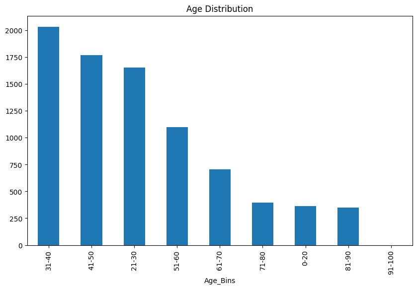

```
Missing values in Ever_Married: 144
Missing values in Graduated: 80
Missing values in Profession: 128
Missing values in Work_Experience: 857
Missing values in Family_Size: 344
```

### Outlier Analysis

```
================================================================================
COMPREHENSIVE OUTLIER DETECTION ANALYSIS
================================================================================
Dataset: 10695 records, 9 columns

 STATISTICAL OUTLIERS (IQR METHOD):
--------------------------------------------------

Age:
  Range: 18 - 89
  Normal range: [-4.5, 87.5]
  Outliers: 90/10695 (0.8%)
  Outlier values: [np.int64(88), np.int64(89)]

Work_Experience:
  Range: 0.0 - 14.0
  Normal range: [-6.0, 10.0]
  Outliers: 247/9597 (2.6%)
  Outlier values: [np.float64(11.0), np.float64(12.0), np.float64(13.0), np.float64(14.0)]

Family_Size:
  Range: 1.0 - 9.0
  Normal range: [-1.0, 7.0]
  Outliers: 125/10247 (1.2%)
  Outlier values: [np.float64(8.0), np.float64(9.0)]


 CATEGORICAL DISTRIBUTION ANALYSIS:
--------------------------------------------------

Gender:
  Male: 5841 (54.6%)
  Female: 4854 (45.4%)

Ever_Married:
  Yes: 6163 (58.7%)
  No: 4342 (41.3%)

Graduated:
  Yes: 6570 (62.0%)
```

[output cut: 76 more lines]

```

 Logical Inconsistencies:
  • Impossible work experience (Work Exp > Age-16): 212 records
  • Unusual graduates (30+ age, 0 exp): 1644 records
  • Young but highly experienced: 53 records

 Data Quality Issues:
  • Missing Ever_Married: 190 records (1.8%)
  • Missing Graduated: 102 records (1.0%)
  • Missing Profession: 162 records (1.5%)
  • Missing Work_Experience: 1098 records (10.3%)
  • Missing Family_Size: 448 records (4.2%)
  • Customer ID duplicates: 4664 records

Creating visualizations...
```

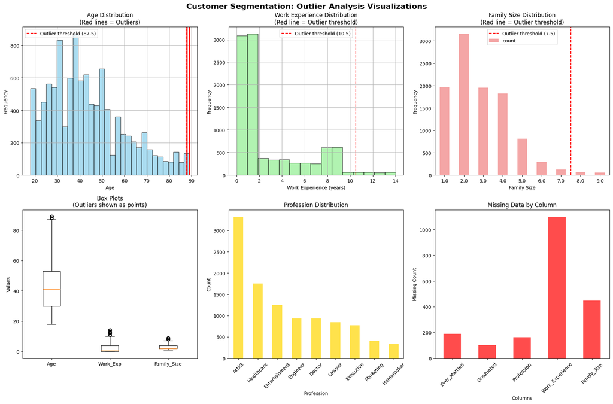

```
============================================================
OUTLIER IMPACT ANALYSIS
============================================================

Age:
  With outliers    - Mean: 43.51, Std: 16.77
  Without outliers - Mean: 43.13, Std: 16.32
  Impact on mean: 0.38
  Impact on std:  0.45

Work_Experience:
  With outliers    - Mean: 2.62, Std: 3.39
  Without outliers - Mean: 2.36, Std: 3.02
  Impact on mean: 0.26
  Impact on std:  0.37

Family_Size:
  With outliers    - Mean: 2.84, Std: 1.54
  Without outliers - Mean: 2.77, Std: 1.41
  Impact on mean: 0.07
  Impact on std:  0.13

 Outlier analysis completed!
 Results stored in 'outlier_results' dictionary
```

## Removing Duplicates

- 2332 duplicate customer ids
- Few records had same data across all features and duplicate IDs - gennuine duplicates - drop
- Few records had same data across all features but no duplicate IDs - might not be duplicates - keep
- most of the records have duplicate customer IDs and same data except for age/work exp - data capture error (same customer at different times) - drop

```
Original dataset: 10695 records
Unique Customer IDs: 8363
Duplicate Customer ID records: 2332
Number of Customer IDs with duplicates: 2332

============================================================

Columns that change across duplicate Customer IDs:
Column Name          Records Affected     Percentage
-------------------------------------------------------
Age                  4118                 88.3%
Work_Experience      2284                 49.0%

============================================================
DEDUPLICATION
============================================================
After deduplication: 8363 records
Records removed: 2332
Unique Customer IDs: 8363

Examples of deduplication decisions:
Customer ID     Original Records   Selected Record Criteria
--------------------------------------------------------------------------------
460394          2                  Age: 32 (from [32, 32]), Work_Exp: 9.0 (from [9.0, 9.0])
460962          2                  Age: 61 (from [55, 61]), Work_Exp: 9.0 (from [9.0, 9.0])
460333          2                  Age: 42 (from [42, 40]), Work_Exp: 10.0 (from [10.0, 12.0])
467208          2                  Age: 41 (from [41, 39]), Work_Exp: nan (from [nan, nan])
466301          2                  Age: 52 (from [50, 52]), Work_Exp: 1.0 (from [0.0, 1.0])

============================================================
Original records: 10695
Deduplicated records: 8363
Records removed: 2332
Duplicate Customer IDs processed: 2332
Most frequently changing column: Age
```

### kNN Imputer

- Uses kNN to predict missing values, considering relationships between all features
- Maintains original distributions and correlations by leveraging information from the k most similar complete records
- Future imporovements - optimize k for each fvariable, select only relevant features for imputation of a particular features, use MICE

```
Dataset shape: (8363, 9)
Missing values per column:
Customer ID          0
Gender               0
Ever_Married       144
Age                  0
Graduated           80
Profession         128
Work_Experience    857
Spending_Score       0
Family_Size        344
dtype: int64

Imputation Quality Check:
========================================
Remaining missing values: 0

Verifying original values were preserved:
  Ever_Married: ✓ Preserved
  Graduated: ✓ Preserved
  Profession: ✓ Preserved
  Work_Experience: ✓ Preserved
  Family_Size: ✓ Preserved

Values imputed per column:
  Ever_Married: 144 values imputed
  Graduated: 80 values imputed
  Profession: 128 values imputed
  Work_Experience: 857 values imputed
  Family_Size: 344 values imputed

Distribution comparison (including imputed values):

Age:
  Original: mean=43.84, std=16.83
  With imputed: mean=43.84, std=16.83

Ever_Married distribution comparison:
  Yes: 58.5% -> 58.3%
  No: 41.5% -> 41.7%
```

[output cut: 38 more lines]

```
  5.0: 8.0% -> 7.7%
  6.0: 2.7% -> 2.8%
  7.0: 1.2% -> 1.2%
  8.0: 0.6% -> 0.6%
  9.0: 0.6% -> 0.6%

Summary:
- Total rows processed: 8363
- Ever_Married: 144 missing values imputed
- Graduated: 80 missing values imputed
- Profession: 128 missing values imputed
- Work_Experience: 857 missing values imputed
- Family_Size: 344 missing values imputed
- Total values imputed: 1553
- Original non-missing values: preserved unchanged
```

## EDA - Customer Demographics & Profile Analysis

- Gender Distribution: 54.8% Male | 45.2% Female
- Age Concentration: ~80% between ages 21-60 (core demographic)
- Education: 62% Graduates | 38% Non-Graduates
- Marital Status: 59% Ever-Married | 41% Never-Married

### Gender & Life Stage Insights:

- Marriage Patterns: Higher % of males ever-married vs. females never married
- Age Distribution: Males dominate younger (0-20) and older (51-70) age groups
- Education Gap: Among non-graduates, males significantly overrepresented

### Professional Landscape:

- Artist Heavy Economy: 31% of population are artists (largest profession)
- Gender Segregation: Females concentrated in Engineering, Homemaker, Marketing; Males in Entertainment, Executive, Healthcare
- Experience Distribution: 62% have 0-1 years work experience (early career dominant ??)

### Family Structure:

- 90% have family sizes 1 - 4
- Single Person Households: Only family size 1 shows female majority
- Career Marriage Correlation: <4% under-30s married; <8% over-40s never married

#### Young, creative population with early career (work exp < 2) suggests growth stage market with high engagement potential but developing spending power

## Spending Pattern Analysis

- Low Spenders: 60% of population (dominant segment)
- Average Spenders: 24% of population
- High Spenders: 14% of population (premium opportunity)
- Gender & Spending Dynamics:
  - Males have higher % composition in Average and High spending groups
- Age-Based Spending Insights:
  - Young Budget Conscious: 45% of low spenders are under 40 years
  - Mature Premium Segment: High spenders consistently 15-20% across 41+ age groups
  - Average spenders concentrate 80% in 31-60 age range
- Professional Spending Behaviors:
  - Premium Professions: Lawyers (52% high spenders) and Executives (65% high spenders)
  - Budget-Constrained Sectors: Healthcare (93% low spenders), Marketing (82% low spenders)
  - Balanced Spenders: Artists, Engineers, Entertainment show average spending patterns
- Marriage & Spending Correlation:
  - Single Budget Focus: 41% of population = never-married low spenders
  - Family Financial Responsibility: 24% = married average spenders
  - Premium Family Segment: 19% = married low spenders (value-conscious families)

#### 60% low-spending base - upselling opportunity ??; 14% premium segment - high value customers

## Segmentation Methodology

### Feature engineering

- Profession Categorization: Grouped careers into skill tiers (High-Skill: Doctor/Engineer/Executive vs Creative vs Service/Care) based on market value and requirements
- Life Stage Classification: Combined age, marital status, and work experience into meaningful life phases - Career Starter, Young Professional, Established Adult, Senior Segment, Transitional
- Economic Capacity Index: Weighted scoring system (0-100) integrating profession tier (40%), education level (30%), and spending behavior (30%) to capture purchasing power
- Family Responsibility Factor: Age-adjusted multiplier accounting for marital status and family size to understand financial obligations and decision-making complexity
- Profession - Education match: boolean variable indicating comparison of job typ and education level (eg: High-Skill and Graduate/Non-Graduate)

### Data preprocesisng pipeline

- Categorical Encoding: OneHotEncoder applied to categorical variables
- Numerical Standardization: StandardScaler used to normalize numerical variable
- Dimensionality Reduction: PCA implemented to capture 95% variance while reducing noise

## Ensemble approach - Multi Algorithm Consensus Clustering

STAGE 1: Algorithm Ensemble

- HDBSCAN → Density-based natural clusters
- K-Means → Centroid-based balanced groups
- Hierarchical → Tree-based relationship mapping

STAGE 2: Consensus Identification

- Cross-algorithm validation
- 76% stable consensus data identified (customers falling into same across the 3 algorithms, and size of cluster >4% )
- 24% edge cases separated for specialized analysis

STAGE 3: Refined Segmentation

- Core segments: 4 stable clusters (high confidence)
- Niche segments: 4 specialized micro-clusters

## tSNE representation of clusters

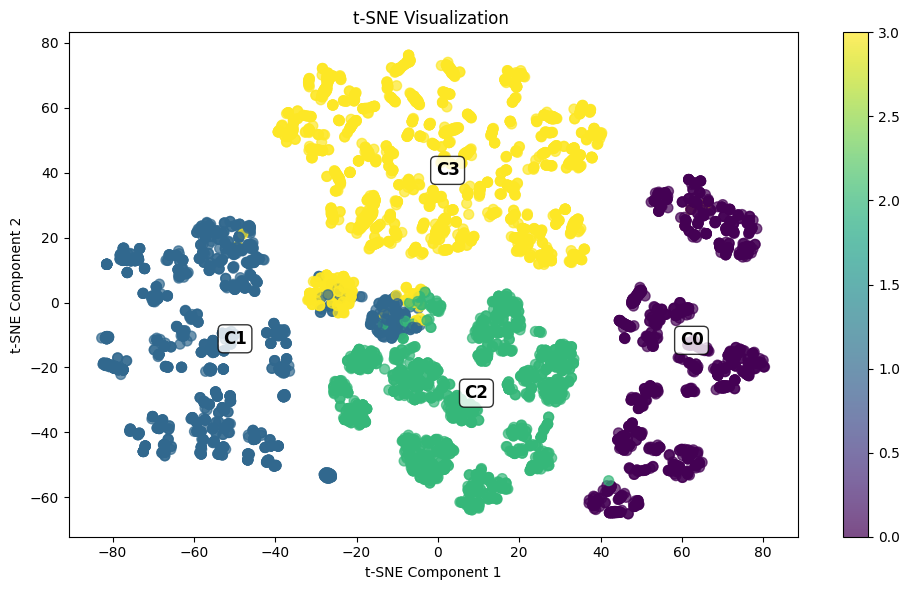

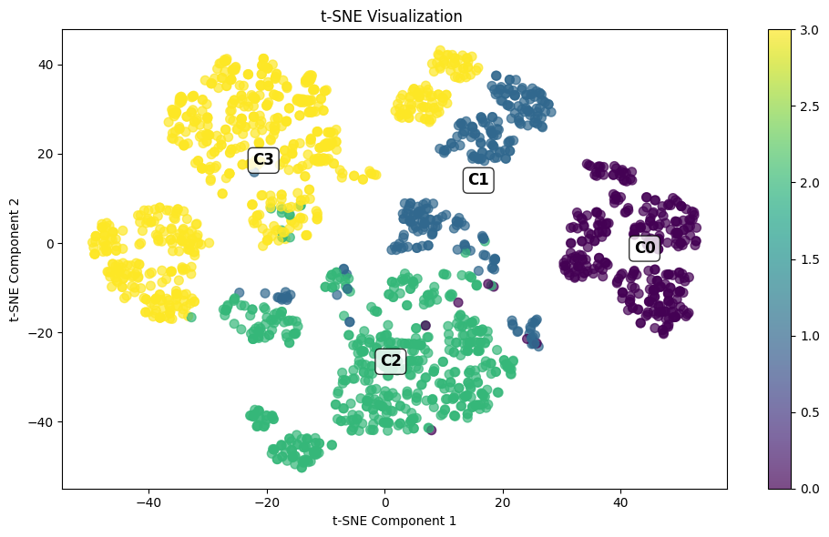

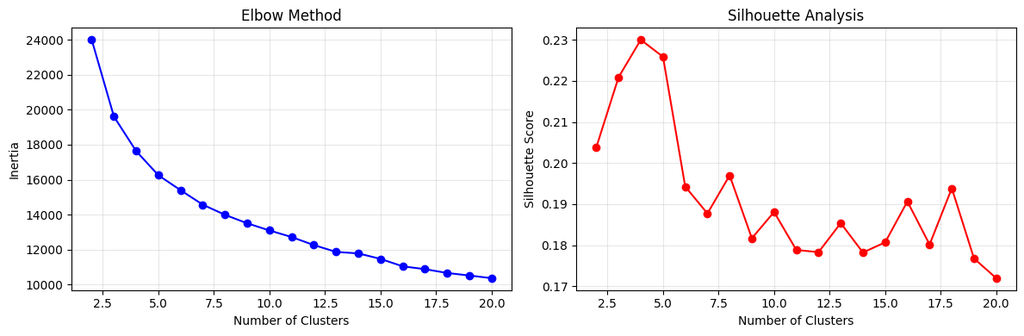

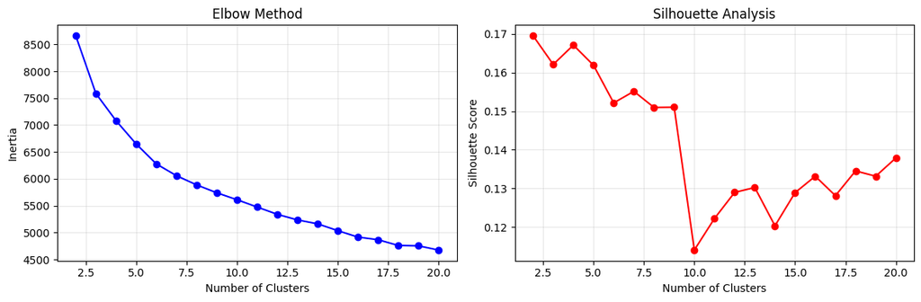

### Cluster profiles

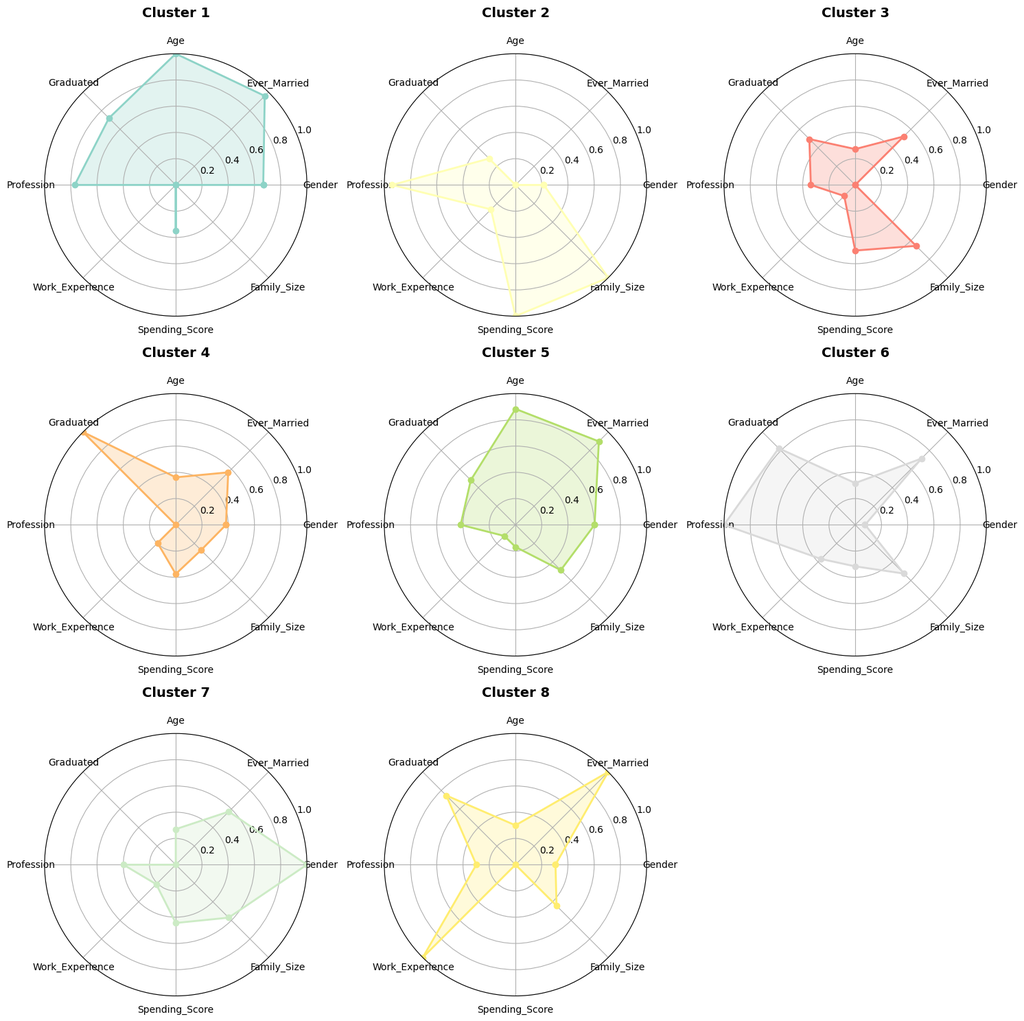